# CLRS 2016 Reserve Example

## Executive Summary

SFR consulting was retained by the CLRS 2016 R Workshop participants to prepare this analysis of unpaid claims and claims expenses. In this document, we present a analysis of unpaid claims and claim expenses. We developed this analysis using `R` and used R Markdown to create this document.

The relevant dates for our analysis are as follows:

- Accounting date: 1997-12-31
- Valuation date: 1997-12-31
- Information date: 1997-12-31

The scope of our analysis is to estimate the unpaid claims and claims expenses for the automobile liability coverage for CLRS Insurance Company.

### Acknowledgement

Any questions related to this report should be directed to:

Rajesh Sahasrabuddhe, FCAS, MAAA  
(215) 246-1028  
rajesh_saharabuddhe@oliverwyman.com

Brian A. Fannin, ACAS

BFannin@RedwoodsGroup.com

Emma Ran Li  
(814) 753-0321  
ril5077@gmail.com

## Setting up the R Environment

We used several R packages to prepare this analysis.

```r
# load packages

my_packages <- list("dplyr", "magrittr", "lubridate", "htmlTable", "knitr",
  "xtable", "ChainLadder", "scales", "highcharter", "ggplot2")
sapply(X = my_packages, FUN = library, character.only = TRUE)
```

## Data

The data underlying this analysis was provided by the Casualty Actuarial Society (CAS) which was available at http://www.casact.org/research/reserve_data/ppauto_pos.csv. We downloaded the data on Tuesday, Aug 09, 2016 at 11:33:59 PM.

We summarize that data in the table below:

| Data Summary as of 1997-12-31 Year | Data Summary as of 1997-12-31 Premium | Data Summary as of 1997-12-31 Incurred | Data Summary as of 1997-12-31 Paid | Data Summary as of 1997-12-31 Case |
| --- | --- | --- | --- | --- |
| 1988 | 7,922,457 | 6,826,501 | 6,815,646 | 10,855 |
| 1989 | 8,893,210 | 7,733,559 | 7,712,077 | 21,482 |
| 1990 | 9,948,988 | 8,405,128 | 8,364,955 | 40,173 |
| 1991 | 10,803,190 | 8,291,065 | 8,215,810 | 75,255 |
| 1992 | 11,690,069 | 9,060,858 | 8,876,813 | 184,045 |
| 1993 | 12,533,746 | 9,714,779 | 9,337,099 | 377,680 |
| 1994 | 13,590,797 | 10,462,749 | 9,640,098 | 822,651 |
| 1995 | 14,401,255 | 10,612,837 | 9,006,113 | 1,606,724 |
| 1996 | 14,900,682 | 10,479,410 | 7,486,113 | 2,993,297 |
| 1997 | 15,065,713 | 10,648,978 | 4,344,144 | 6,304,834 |
| Total | 119,750,107 | 92,235,864 | 79,798,868 | 12,436,996 |

## Loss Development

### Paid Loss Development Experience

We present paid loss development experience in the triangle below.

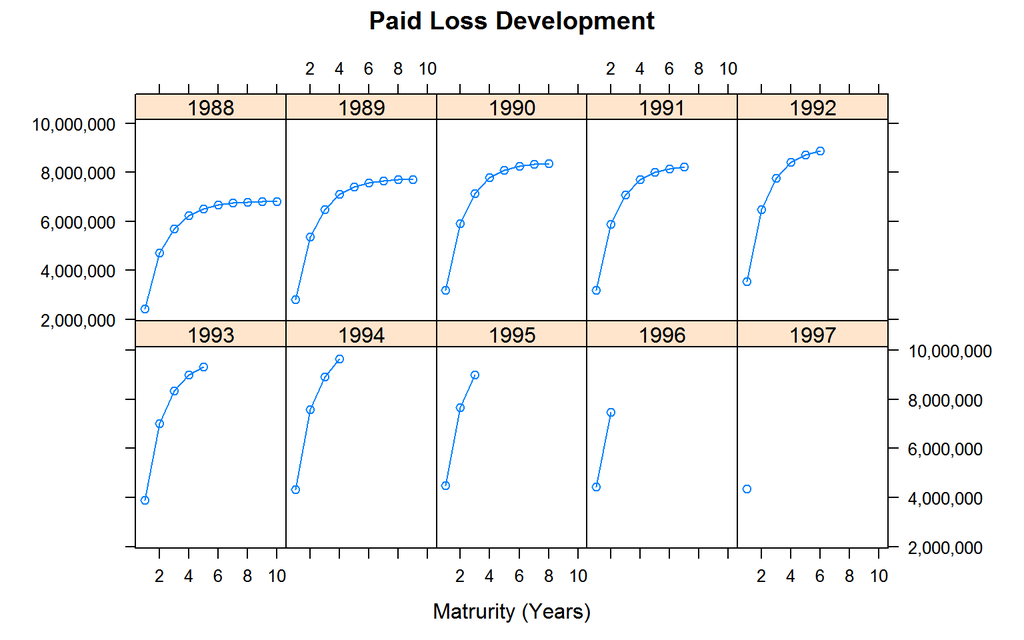

### Incurred Loss Development Experience

We present incurred loss development experience in the triangle below:

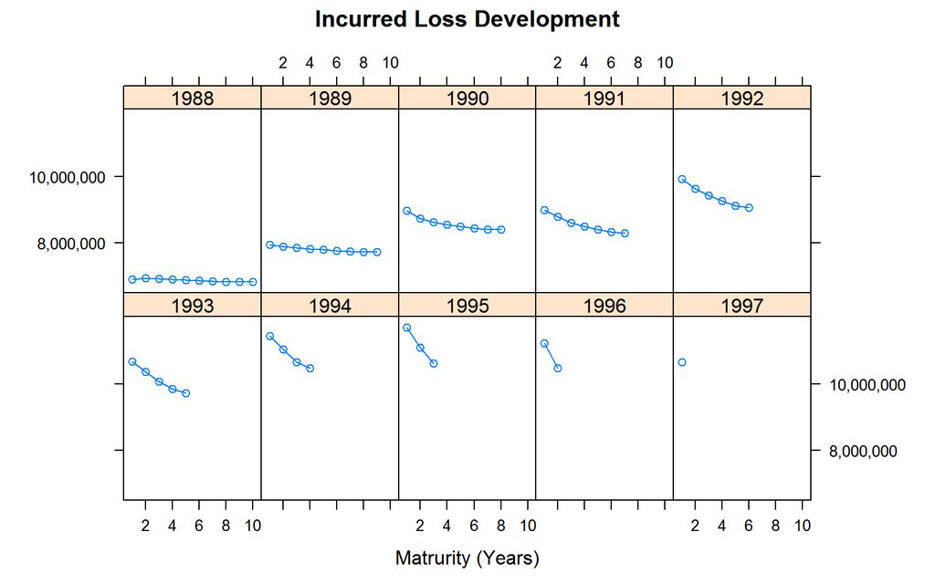

## Ultimate Loss Projections

We used the `R` package `ChainLadder` to project ultimate losses using the following methods:

### Mack-Chain-Ladder Model

```r
mcl_paid <- MackChainLadder(Triangle = my_triangles$paid)
mcl_paid
```

```
## MackChainLadder(Triangle = my_triangles$paid)
##
##         Latest Dev.To.Date   Ultimate      IBNR Mack.S.E CV(IBNR)
## 1988 6,815,646       1.000  6,815,646         0        0      NaN
## 1989 7,712,077       0.999  7,719,821     7,744    1,549   0.2000
## 1990 8,364,955       0.996  8,396,601    31,646    5,103   0.1613
## 1991 8,215,810       0.991  8,288,545    72,735    6,042   0.0831
## 1992 8,876,813       0.982  9,043,728   166,915   10,809   0.0648
## 1993 9,337,099       0.962  9,702,726   365,627   26,568   0.0727
## 1994 9,640,098       0.925 10,422,621   782,523   45,702   0.0584
## 1995 9,006,113       0.852 10,571,471 1,565,358   71,775   0.0459
## 1996 7,486,113       0.714 10,490,872 3,004,759  146,538   0.0488
## 1997 4,344,144       0.397 10,933,658 6,589,514  508,516   0.0772
##
##                  Totals
## Latest:   79,798,868.00
## Dev:               0.86
## Ultimate: 92,385,689.36
## IBNR:     12,586,821.36
## Mack.S.E     549,869.43
## CV(IBNR):          0.04
```

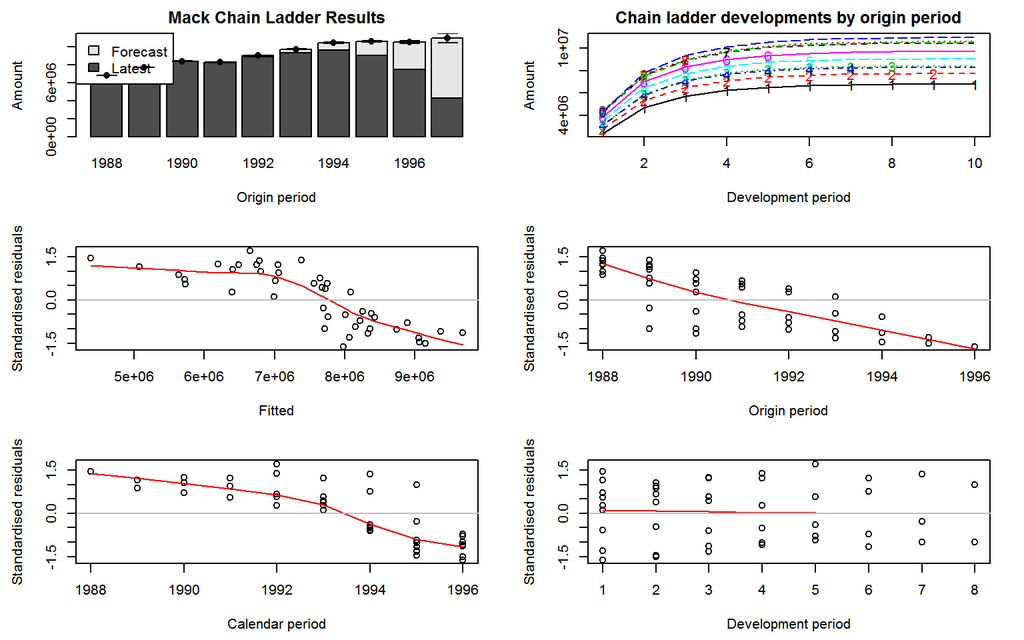

```r
plot(mcl_paid)
```

```r
mcl_incurred <- MackChainLadder(Triangle = my_triangles$incurred)
mcl_incurred
```

```
## MackChainLadder(Triangle = my_triangles$incurred)
##
##          Latest Dev.To.Date   Ultimate     IBNR Mack.S.E CV(IBNR)
## 1988  6,826,501        1.00  6,826,501        0        0      NaN
## 1989  7,733,559        1.00  7,730,688   -2,871    1,399   -0.487
## 1990  8,405,128        1.00  8,402,250   -2,878    2,975   -1.034
## 1991  8,291,065        1.00  8,285,251   -5,814    5,140   -0.884
## 1992  9,060,858        1.01  9,013,604  -47,254    7,495   -0.159
## 1993  9,714,779        1.01  9,611,411 -103,368   32,760   -0.317
## 1994 10,462,749        1.02 10,254,451 -208,298   62,572   -0.300
## 1995 10,612,837        1.03 10,268,035 -344,802   95,934   -0.278
## 1996 10,479,410        1.06  9,903,561 -575,849  170,716   -0.296
## 1997 10,648,978        1.09  9,739,379 -909,599  272,002   -0.299
##
##                  Totals
## Latest:   92,235,864.00
## Dev:               1.02
## Ultimate: 90,035,131.06
## IBNR:     -2,200,732.94
## Mack.S.E     370,195.79
## CV(IBNR):         -0.17
```

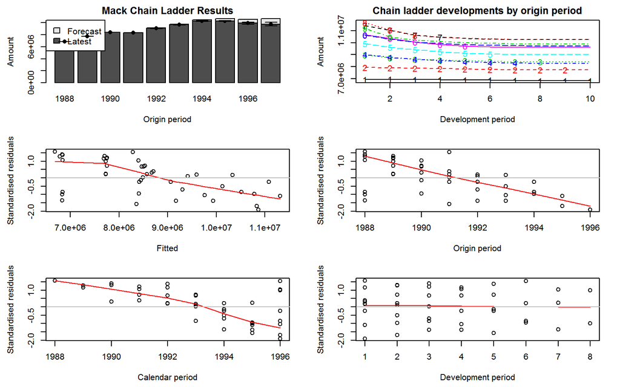

```r
plot(mcl_incurred)
```

### Bootstrap-Chain-Ladder Model

```r
bcl_paid <- BootChainLadder(Triangle = my_triangles$paid, R = 999,
  process.distr = "gamma")
bcl_paid
```

```
## BootChainLadder(Triangle = my_triangles$paid, R = 999, process.distr = "gamma")
##
##         Latest Mean Ultimate Mean IBNR IBNR.S.E  IBNR 75%  IBNR 95%
## 1988 6,815,646     6,815,646         0        0         0         0
## 1989 7,712,077     7,719,859     7,782   10,210    12,840    27,765
## 1990 8,364,955     8,397,138    32,183   18,168    42,461    63,103
## 1991 8,215,810     8,289,333    73,523   26,938    88,901   123,279
## 1992 8,876,813     9,045,129   168,316   39,258   191,912   238,411
## 1993 9,337,099     9,705,778   368,679   55,865   405,079   465,269
## 1994 9,640,098    10,426,060   785,962   79,736   837,976   916,489
## 1995 9,006,113    10,573,493 1,567,380  120,343 1,650,688 1,767,586
## 1996 7,486,113    10,491,443 3,005,330  172,162 3,119,470 3,277,694
## 1997 4,344,144    10,937,567 6,593,423  330,188 6,796,611 7,131,345
##
##                     Totals
## Latest:         79,798,868
## Mean Ultimate:  92,401,445
## Mean IBNR:      12,602,577
## IBNR.S.E           467,327
## Total IBNR 75%: 12,908,684
## Total IBNR 95%: 13,366,050
```

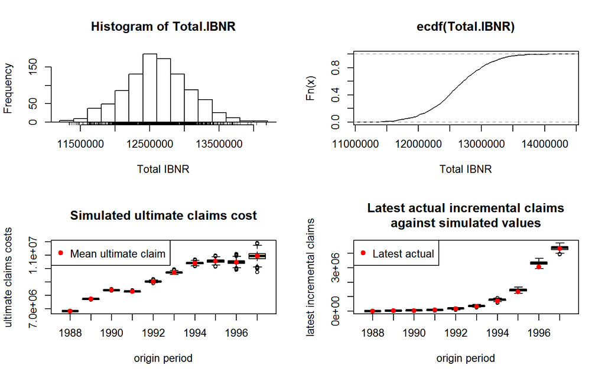

```r
plot(bcl_paid)
```

```r
bcl_incurred <- BootChainLadder(Triangle = my_triangles$incurred, R = 999, process.distr = "gamma")
bcl_incurred
```

```
## BootChainLadder(Triangle = my_triangles$incurred, R = 999, process.distr = "gamma")
##
##          Latest Mean Ultimate Mean IBNR IBNR.S.E  IBNR 75% IBNR 95%
## 1988  6,826,501     6,826,501         0        0  0.00e+00        0
## 1989  7,733,559     7,731,648    -1,911   26,488  2.16e+00   29,164
## 1990  8,405,128     8,404,740      -388   32,948  7.63e+01   35,670
## 1991  8,291,065     8,285,389    -5,676   42,993  5.78e+02   41,774
## 1992  9,060,858     9,016,148   -44,710   74,350 -3.28e+03   35,054
## 1993  9,714,779     9,616,983   -97,796   97,325 -2.94e+04    5,807
## 1994 10,462,749    10,259,101  -203,648  132,480 -1.06e+05  -28,994
## 1995 10,612,837    10,283,300  -329,537  165,355 -2.04e+05 -105,769
## 1996 10,479,410     9,912,007  -567,403  221,718 -4.03e+05 -260,686
## 1997 10,648,978     9,757,286  -891,692  276,111 -6.95e+05 -493,617
##
##                     Totals
## Latest:         92,235,864
## Mean Ultimate:  90,093,102
## Mean IBNR:      -2,142,762
## IBNR.S.E           533,841
## Total IBNR 75%: -1,769,999
## Total IBNR 95%: -1,311,766
```

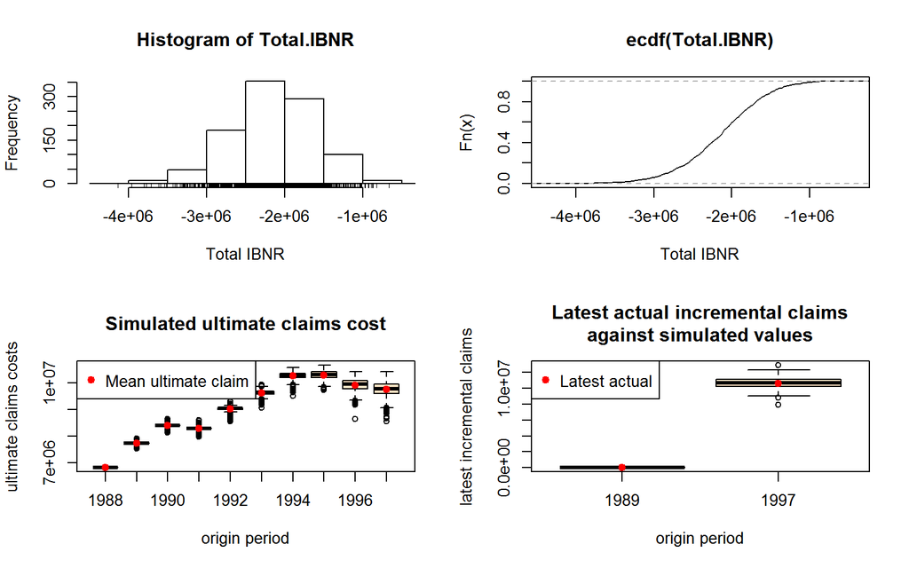

```r
plot(bcl_incurred)
```

### Munich-Chain-Ladder Model

```r
munich <- MunichChainLadder(Paid = my_triangles$paid, Incurred = my_triangles$incurred,
  est.sigmaP = 0.1, est.sigmaI = 0.1)
munich
```

```
## MunichChainLadder(Paid = my_triangles$paid, Incurred = my_triangles$incurred,
##     est.sigmaP = 0.1, est.sigmaI = 0.1)
##
##      Latest Paid Latest Incurred Latest P/I Ratio  Ult. Paid Ult. Incurred
## 1988   6,815,646       6,826,501            0.998  6,815,646     6,826,501
## 1989   7,712,077       7,733,559            0.997  7,719,654     7,730,629
## 1990   8,364,955       8,405,128            0.995  8,392,987     8,401,359
## 1991   8,215,810       8,291,065            0.991  8,277,687     8,282,288
## 1992   8,876,813       9,060,858            0.980  9,007,620     9,004,087
## 1993   9,337,099       9,714,779            0.961  9,594,069     9,576,316
## 1994   9,640,098      10,462,749            0.921 10,201,439    10,171,389
## 1995   9,006,113      10,612,837            0.849 10,142,317    10,095,103
## 1996   7,486,113      10,479,410            0.714  9,616,895     9,547,866
## 1997   4,344,144      10,648,978            0.408  9,335,620     9,266,960
##      Ult. P/I Ratio
## 1988          0.998
## 1989          0.999
## 1990          0.999
## 1991          0.999
## 1992          1.000
## 1993          1.002
## 1994          1.003
## 1995          1.005
## 1996          1.007
## 1997          1.007
##
## Totals
##              Paid Incurred P/I Ratio
## Latest:   8.0e+07  9.2e+07      0.87
## Ultimate: 8.9e+07  8.9e+07      1.00
```

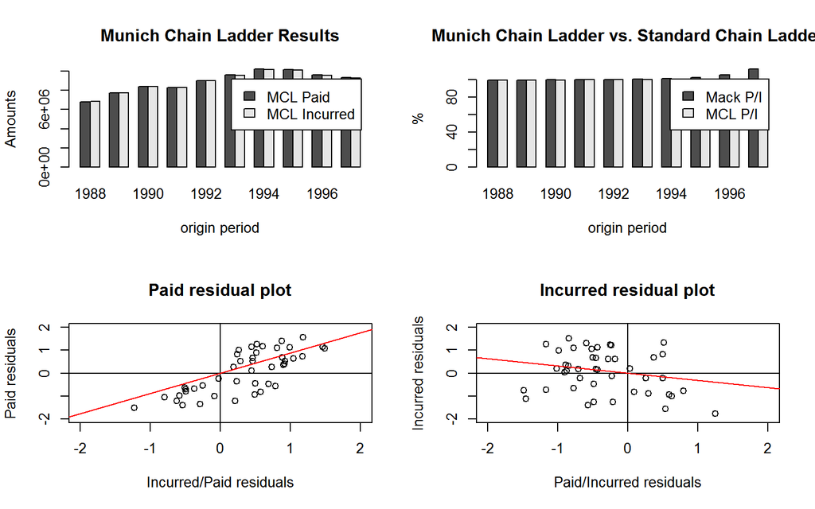

```r
plot(munich)
```

In the chart below, we first present the observed incremental development factors.

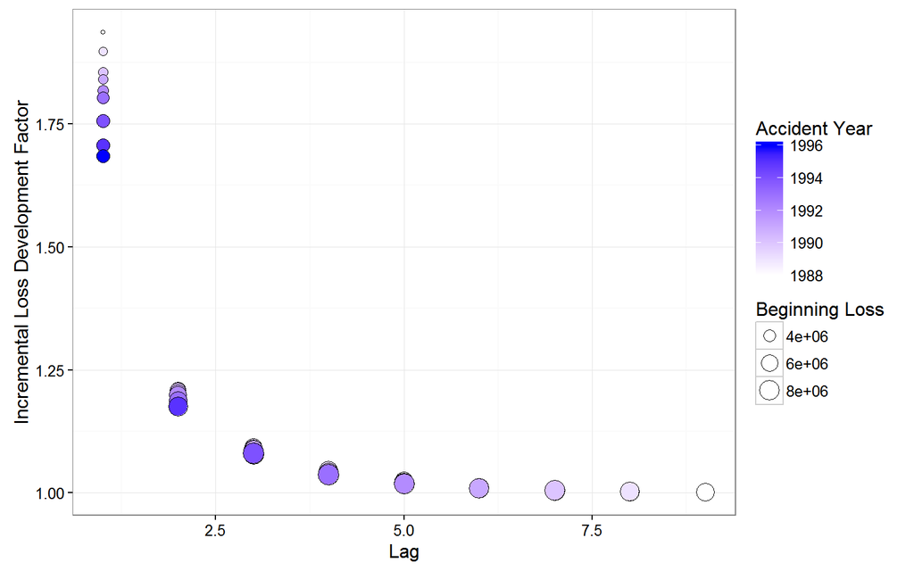

```r
paid_dev_analysis <- dev_factor_df(my_triangles$paid)
paid_dev_analysis$gg
```

We then select the following development factors:

```r
paid_dev_analysis$sel_ldf_df$sel_ldf = c(
  1.72, 1.18, 1.08,
  1.04, 1.02, 1.01,
  1.00, 1.00, 1.00)

paid_dev_analysis$sel_ldf_df$sel_cldf <- paid_dev_analysis$sel_ldf_df$sel_ldf %>%
  rev() %>%
  cumprod() %>%
  rev()

paid_tail <- 1.02

paid_dev_analysis$sel_ldf_df$sel_cldf <-
  paid_dev_analysis$sel_ldf_df$sel_cldf * paid_tail


paid_dev_analysis$sel_ldf_df
```

```
## Source: local data frame [9 x 3]
##
##     lag sel_ldf sel_cldf
##   <dbl>   <dbl>    <dbl>
## 1     1    1.72 2.395462
## 2     2    1.18 1.392710
## 3     3    1.08 1.180263
## 4     4    1.04 1.092836
## 5     5    1.02 1.050804
## 6     6    1.01 1.030200
## 7     7    1.00 1.020000
## 8     8    1.00 1.020000
## 9     9    1.00 1.020000
```

We now add our selected incremental loss development factors (in red) to the chart.

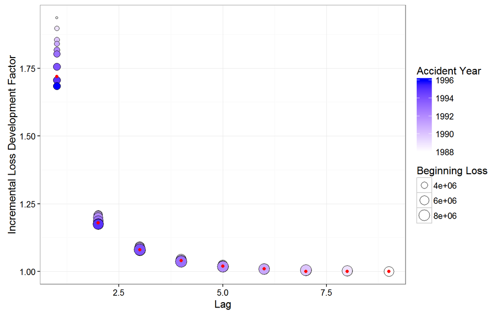

## Comparison of Methods

We now compare estimates by method

```r
ultimates <- data_frame(acc_yr = row.names(summary(bcl_incurred)$ByOrigin),
  bcl_incurred = summary(bcl_incurred)$ByOrigin$'Mean Ultimate',
  bcl_paid = summary(bcl_paid)$ByOrigin$'Mean Ultimate',
  mcl_incurred = summary(mcl_incurred)$ByOrigin$'Ultimate',
  mcl_paid = summary(mcl_paid)$ByOrigin$'Ultimate',
  munich_incurred = summary(munich)$ByOrigin$'Ult. Incurred',
  munich_paid = summary(munich)$ByOrigin$'Ult. Paid',
  incurred = summary(munich)$ByOrigin$'Latest Incurred',
  paid = summary(munich)$ByOrigin$'Latest Paid')


ultimates
```

```
## Source: local data frame [10 x 9]
##
##    acc_yr bcl_incurred bcl_paid mcl_incurred mcl_paid munich_incurred
##     <chr>        <dbl>    <dbl>        <dbl>    <dbl>           <dbl>
## 1    1988      6826501  6815646      6826501  6815646         6826501
## 2    1989      7731648  7719859      7730688  7719821         7730629
## 3    1990      8404740  8397138      8402250  8396601         8401359
## 4    1991      8285389  8289333      8285251  8288545         8282288
## 5    1992      9016148  9045129      9013604  9043728         9004087
## 6    1993      9616983  9705778      9611411  9702726         9576316
## 7    1994     10259101 10426060     10254451 10422621        10171389
## 8    1995     10283300 10573493     10268035 10571471        10095103
## 9    1996      9912007 10491443      9903561 10490872         9547866
## 10   1997      9757286 10937567      9739379 10933658         9266960
## Variables not shown: munich_paid <dbl>, incurred <dbl>, paid <dbl>.
```

[interactive chart not shown]

## R packages

We used the following `R` packages to develop this analysis:

- Base R: R Core Team (2016). R: A language and environment for statistical computing. R Foundation for Statistical Computing, Vienna, Austria. URL https://www.R-project.org/.

We used `rmdformats` to produce this report.

- rmdformats: Julien Barnier (2016). rmdformats: HTML Output Formats and Templates for ‘rmarkdown’ Documents. R package version 0.2. https://CRAN.R-project.org/package=rmdformats
- Hadley Wickham and Romain Francois (2016). dplyr: A Grammar of Data Manipulation. R package version 0.5.0. https://CRAN.R-project.org/package=dplyr
- Stefan Milton Bache and Hadley Wickham (2014). magrittr: A Forward-Pipe Operator for R. R package version 1.5. https://CRAN.R-project.org/package=magrittr
- Garrett Grolemund, Hadley Wickham (2011). Dates and Times Made Easy with lubridate. Journal of Statistical Software, 40(3), 1-25. URL http://www.jstatsoft.org/v40/i03/.
- Max Gordon (2016). htmlTable: Advanced Tables for Markdown/HTML. R package version 1.5. https://CRAN.R-project.org/package=htmlTable
- Yihui Xie (2016). knitr: A General-Purpose Package for Dynamic Report Generation in R. R package version 1.13.
- Yihui Xie (2015) Dynamic Documents with R and knitr. 2nd edition. Chapman and Hall/CRC. ISBN 978-1498716963
- Yihui Xie (2014) knitr: A Comprehensive Tool for Reproducible Research in R. In Victoria Stodden, Friedrich Leisch and Roger D. Peng, editors, Implementing Reproducible Computational Research. Chapman and Hall/CRC. ISBN 978-1466561595
- David B. Dahl (2016). xtable: Export Tables to LaTeX or HTML. R package version 1.8-2. https://CRAN.R-project.org/package=xtable
- Markus Gesmann, Daniel Murphy, Yanwei (Wayne) Zhang, Alessandro Carrato, Giuseppe Crupi, Mario Wuthrich and Fabio Concina (2015). ChainLadder: Statistical Methods and Models for Claims Reserving in General Insurance. R package version 0.2.2. https://CRAN.R-project.org/package=ChainLadder
- Hadley Wickham (2016). scales: Scale Functions for Visualization. R package version 0.4.0. https://CRAN.R-project.org/package=scales
- Joshua Kunst (2016). highcharter: A Wrapper for the ‘Highcharts’ Library. R package version 0.3.0. https://CRAN.R-project.org/package=highcharter
- H. Wickham. ggplot2: Elegant Graphics for Data Analysis. Springer-Verlag New York, 2009.

SFR Actuarial Consulting, Inc.

2016-08-09